# Reproducible Research: Peer assessment 1

Magnolia Lara

8/9/2018

### INTRODUCTION

This document presents the results regarding the Peer asingment fo Reproductible research week 2.

This assignment makes use of data from a personal activity monitoring device. This device collects data at 5 minute intervals through out the day. The data consists of two months of data from an anonymous individual collected during the months of October and November, 2012 and include the number of steps taken in 5 minute intervals each day.

##### This document presents the answers for the following questions regarding the Activity Monitoring Data

1.- What is mean total number of steps taken per day? 2.- What is the average daily activity pattern? 3.-Are there differences in activity patterns between weekdays and weekends?

Firstly, get the packages you need

```r
library(dplyr)
```

```r
library(ggplot2)
```

Load the data into your environment using read.csv()

```r
activity <- read.csv("activity.csv")
```

Look at your data

```r
str(activity)
```

```
## 'data.frame':    17568 obs. of  3 variables:
##  $ steps   : int  NA NA NA NA NA NA NA NA NA NA ...
##  $ date    : Factor w/ 61 levels "2012-10-01","2012-10-02",..: 1 1 1 1 1 1 1 1 1 1 ...
##  $ interval: int  0 5 10 15 20 25 30 35 40 45 ...
```

```r
summary(activity)
```

```
##      steps                date          interval
##  Min.   :  0.00   2012-10-01:  288   Min.   :   0.0
##  1st Qu.:  0.00   2012-10-02:  288   1st Qu.: 588.8
##  Median :  0.00   2012-10-03:  288   Median :1177.5
##  Mean   : 37.38   2012-10-04:  288   Mean   :1177.5
##  3rd Qu.: 12.00   2012-10-05:  288   3rd Qu.:1766.2
##  Max.   :806.00   2012-10-06:  288   Max.   :2355.0
##  NA's   :2304     (Other)   :15840
```

```r
head(activity)
```

```
##   steps       date interval
## 1    NA 2012-10-01        0
## 2    NA 2012-10-01        5
## 3    NA 2012-10-01       10
## 4    NA 2012-10-01       15
## 5    NA 2012-10-01       20
## 6    NA 2012-10-01       25
```

Remove the missing values

```r
act.complete <- na.omit(activity)
```

Try dplyr library to sort by day and summarize the steps

```r
act.day <- group_by(act.complete, date)
act.day <- summarize(act.day, steps=sum(steps))
```

Look at the data per day

```r
summary(act.day)
```

```
##          date        steps
##  2012-10-02: 1   Min.   :   41
##  2012-10-03: 1   1st Qu.: 8841
##  2012-10-04: 1   Median :10765
##  2012-10-05: 1   Mean   :10766
##  2012-10-06: 1   3rd Qu.:13294
##  2012-10-07: 1   Max.   :21194
##  (Other)   :47
```

##### Plot the histogram of the total steps per day

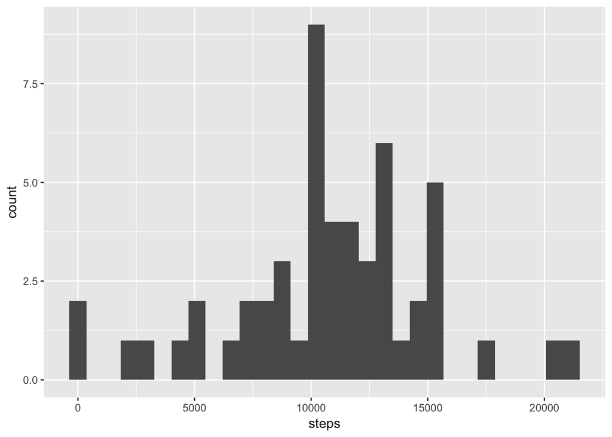

```r
qplot(steps, data=act.day)
```

### Calculate the mean and median

```r
mean(act.day$steps)
```

```
## [1] 10766.19
```

```r
median(act.day$steps)
```

```
## [1] 10765
```

### What is the average daily activity pattern?

Store a data frame in which steps are aggregated into averages within each 5 minute interval: ##### First I create a data frame in which steps are aggregated into averages within each 5 minute interval:

```r
act.int <- group_by(act.complete, interval)
act.int <- summarize(act.int, steps=mean(steps))
```

Plot the average daily steps ##### Next I plot the average daily steps against the intervals:

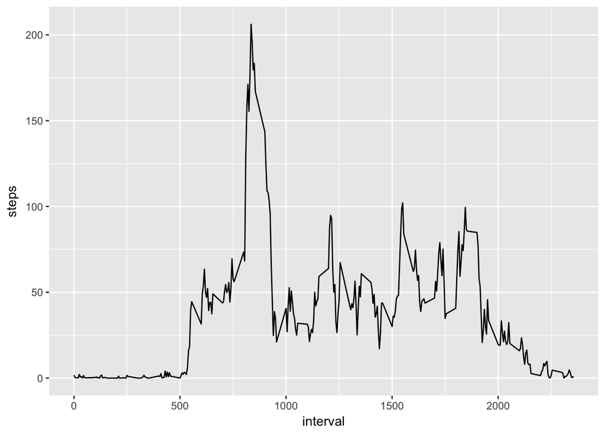

```r
ggplot(act.int, aes(interval, steps)) + geom_line()
```

### The 5-minute interval that, on average, contains the maximum number of steps

```r
act.int[act.int$steps==max(act.int$steps),]
```

```
## # A tibble: 1 x 2
##   interval    steps
##      <int>    <dbl>
## 1      835 206.1698
```

### Check the recuency of the missing values

```r
nrow(activity)-nrow(act.complete)
```

```
## [1] 2304
```

Fill in all of the missing values in the dataset. The strategy does not need to be sophisticated. replace missing values with the mean number of steps for each interval across all of the days. The act.int data frame contains these means.

```r
names(act.int)[2] <- "mean.steps"
act.impute <- merge(activity, act.int)
```

#### Create a new dataset that is equal to the original dataset but with the missing data filled in.

```r
act.impute$steps[is.na(act.impute$steps)] <- act.impute$mean.steps[is.na(act.impute$steps)]
```

Plot the histogram of the total number of steps taken each day and Calculate and report the mean and median total number of steps taken per day. Do these values differ from the estimates from the first part of the assignment? ##### I first create a dataset with the total number of steps per day using the imputed data:

```r
act.day.imp <- group_by(act.impute, date)
act.day.imp <- summarize(act.day.imp, steps=sum(steps))
```

##### I generate the histogram and summary statistics:

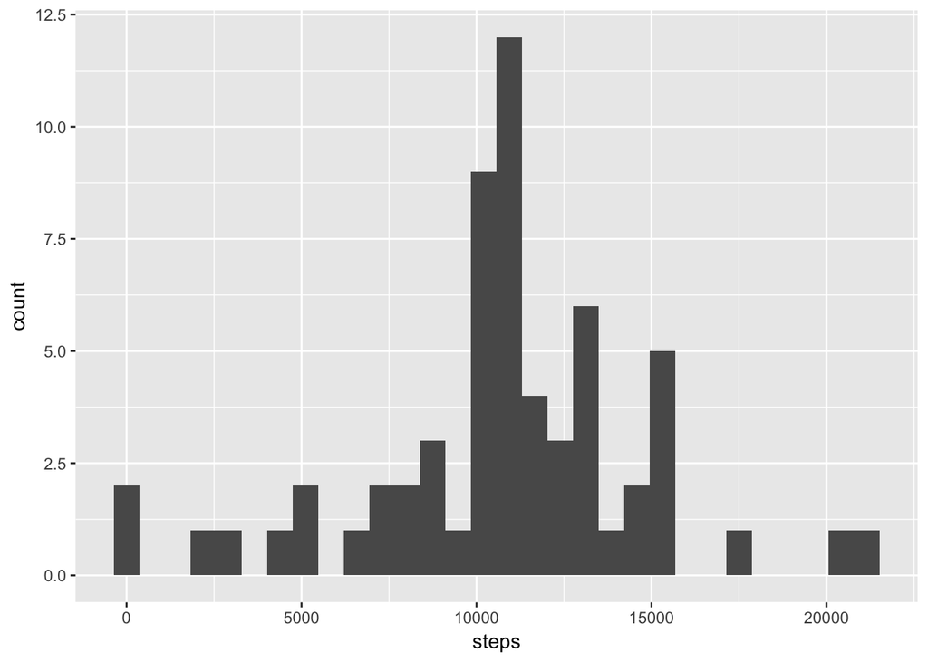

```r
qplot(steps, data=act.day.imp)
```

### Mean and Median

```r
mean(act.day.imp$steps)
```

```
## [1] 10766.19
```

```r
median(act.day.imp$steps)
```

```
## [1] 10766.19
```

### Are there differences in activity patterns between weekdays and weekends?

```r
act.impute$dayofweek <- weekdays(as.Date(act.impute$date))
act.impute$weekend <-as.factor(act.impute$dayofweek=="Saturday"|act.impute$dayofweek=="Sunday")
levels(act.impute$weekend) <- c("Weekday", "Weekend")
```

##### First I create separate data frames for weekends and weekdays:

```r
act.weekday <- act.impute[act.impute$weekend=="Weekday",]
act.weekend <- act.impute[act.impute$weekend=="Weekend",]
```

##### Later for each one, I find the mean number of steps across days for each 5 minute interval:

```r
act.int.weekday <- group_by(act.weekday, interval)
act.int.weekday <- summarize(act.int.weekday, steps=mean(steps))
act.int.weekday$weekend <- "Weekday"
act.int.weekend <- group_by(act.weekend, interval)
act.int.weekend <- summarize(act.int.weekend, steps=mean(steps))
act.int.weekend$weekend <- "Weekend"
```

##### I append the two data frames together, and I make the two time series plots:

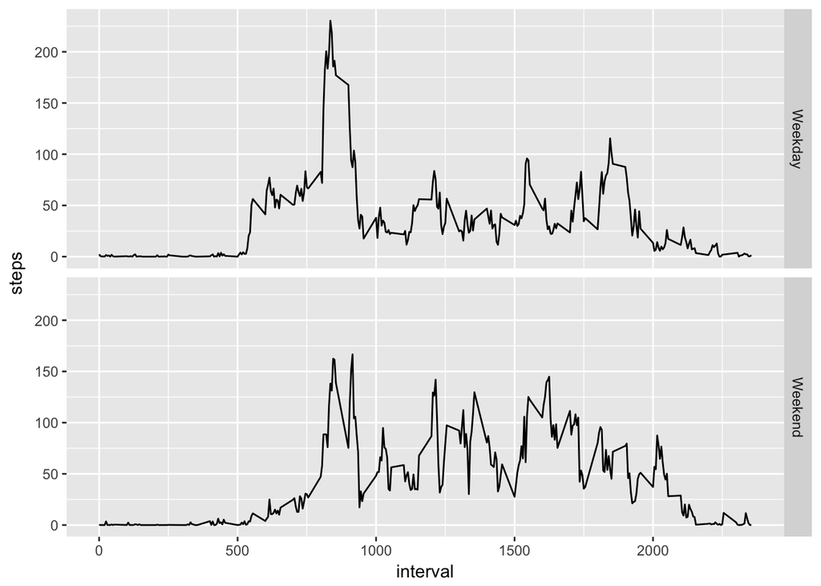

```r
act.int <- rbind(act.int.weekday, act.int.weekend)
act.int$weekend <- as.factor(act.int$weekend)
ggplot(act.int, aes(interval, steps)) + geom_line() + facet_grid(weekend ~ .)
```